The intent of this document is to illustrate some of the efficiencies that can be gained from implementing functions in `Rcpp` compared to their higher level implementations in R.

## Setup

```r
knitr::opts_chunk$set(
    echo = TRUE,
    out.width = "80%"
)
```

```r
library(tidyverse)
library(Rcpp)
options(tibble.width = Inf)
```

## R equations

The set of functions being used to illustrate differences between R code and Rcpp code. The main function being test is: `full_balance`.

```r
sy <- function(x, cond) {
  out <- ifelse(cond < x, 1, 0)
  out <- 1 - (sum(out) / length(x))
  ifelse(out <= 0.01, 0.01, out)
}

new_cond <- function(curr, addit, subtrac, microt) {
  sy_cond <- sy(microt, curr)
  curr + (addit + subtrac) / sy_cond
}

full_balance <- function(iterations, initial, addition, subtraction, add_sd,
  sub_sd, microtopo) {
  #Initialize
  N <- length(addition) #rows
  M <- iterations #columns
  out <- matrix(nrow = N, ncol = M)
  out[1,] <- initial
  add_error <- matrix(rep(addition, times = M) + rnorm(N * M, 0, add_sd),
    nrow = N, ncol = M, byrow = FALSE)
  sub_error <- matrix(rep(subtraction, times = M) + rnorm(N * M, 0, sub_sd),
    nrow = N, ncol = M, byrow = FALSE)
  #Execute
  for(i in 1:iterations) { #columns
    for(j in 2:length(addition)) { #rows
      out[j, i] <- new_cond(out[j - 1, i], add_error[j, i], sub_error[j, i],
        microtopo)
    }
  }
  #Return
  as.data.frame(out)
}
```

## C++ (Rcpp) equations

Similar functions to those above, but implemented in C++ via the Rcpp package. The main function being test is: `full_balance_cpp`.

```cpp
#include <Rcpp.h>
using namespace Rcpp;

// [[Rcpp::export]]
double sy_cpp(NumericVector x, double cond) {
  //Declare
  int N = x.length();
  NumericVector cond_sum(N);
  double out;
  //First ifelse()
  // Short-hand form:
  for(int i = 0; i < N; i++) {
    cond_sum[i] = (cond < x[i] ? 1 : 0);
  }
  //`out` line
  out = 1 - (sum(cond_sum) / N);
  //Second ifelse()
  if(out <= 0.01) {
    out = 0.01;
  }
  //Explicit return statement
  return out;
}

// [[Rcpp::export]]
double new_cond_cpp(double curr, double addit, double subtrac,
  NumericVector microt) {
  //Declare
  double sy_cond;
  double out;
  //Execute
  sy_cond = sy_cpp(microt, curr);
  out = curr + (addit + subtrac) / sy_cond;
  //Return
  return out;
}

// [[Rcpp::export]]
DataFrame full_balance_cpp(int iterations, double initial,
  NumericVector addition, NumericVector subtraction, double add_sd,
  double sub_sd, NumericVector microtopo) {
  //Declare
  int N = addition.length(); //Rows
  int M = iterations; //Columns
  NumericMatrix add_error(N, M);
  NumericMatrix sub_error(N, M);
  NumericMatrix out_mat(N, M);

  //Initialize
  //Set initial conditions for each iteration
  for(int i = 0; i < M; ++i) {
    out_mat(0,i) = initial; //Note `out()` instead of `out[]` for indexing matrices
  }

  //Execute
  //Matrix of observations with error
  for(int i = 0; i < M; ++i) {
    add_error(_, i) = addition + rnorm(N, 0 , add_sd);
    sub_error(_, i) = subtraction + rnorm(N, 0 , add_sd);
  }
  //Loop through each set of observations
  for(int i = 0; i < M; ++i) {
    for(int j = 1; j < N; ++j){
      out_mat(j, i) = new_cond_cpp(out_mat(j - 1, i), add_error(j, i),
        sub_error(j, i), microtopo);
    }
  }

  //Return a dataframe of results
  //Explicit coercion to a different, compatable type following the pattern:
  // as<type>(object)
  DataFrame out = as<DataFrame>(out_mat);
  return out;
}
```

## Data

Some data being used test the different functions.

```r
per_obs <- 1:200
per_n <- length(per_obs)

add_means <- 0.5 * (sin(seq(0, 2 * per_n / 100 * pi, length.out = per_n))) +
  abs(rnorm(per_obs))
add_means <- ifelse(add_means < 0 , 0, add_means)
sub_means <- 0.75 * (cos(seq(0, 2 * per_n / 100 * pi, length.out = per_n)) - 2) +
  abs(rnorm(per_obs))
sub_means <- ifelse(sub_means > 0 , 0, sub_means)

add_sds <- 1
sub_sds <- 1

init_cond <- 0

micro <- map2(.x = c(-4, -2, 0, 2, 5), .y = c(3, 1, 2, 4, 1),
  ~ rnorm(2000, .x, .y)) %>%
  simplify()
```

## Data visualization

Just to give an idea of what the data looks like. This problem was originally conceived of as a time series.

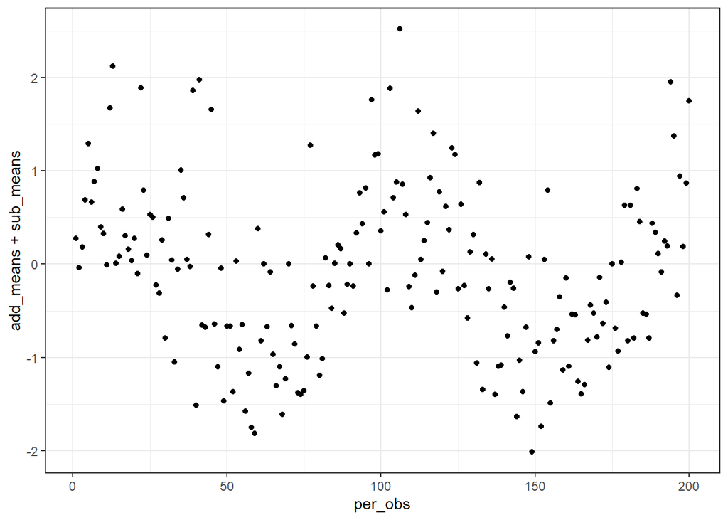

```r
qplot(per_obs, add_means + sub_means) + theme_bw()
```

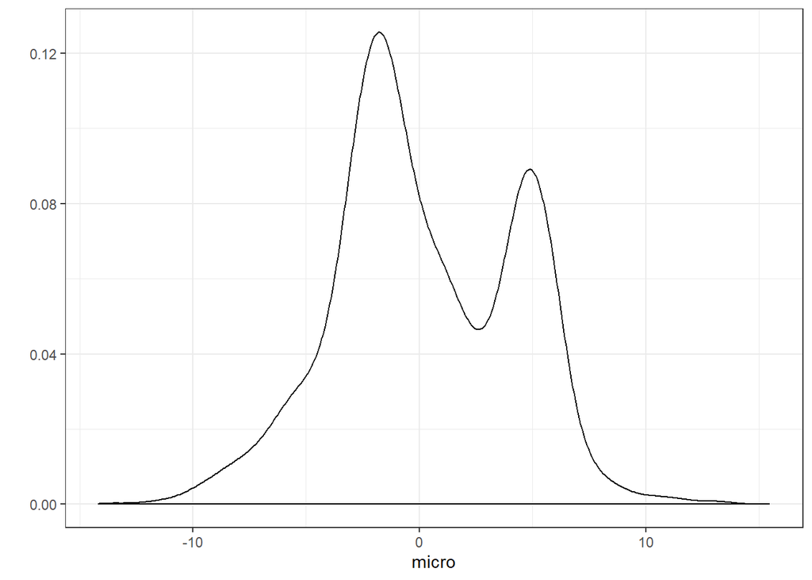

```r
qplot(micro, geom = "density") + theme_bw()
```

## Benchmarking

Here I’m using the `bench` package to iterate over different parameter sets, so we may get an idea of how the two equivalent functions respond to changes in function conditions.

### Run the benchmarks

```r
micro_maker <- function(obs) {
  map2(.x = c(-4, -2, 0, 2, 5), .y = c(3, 1, 2, 4, 1),
  ~ rnorm(obs, .x, .y)) %>%
  simplify()
}

iter_maker <- function(iters) {
  iters
}

bench_press <- bench::press(
  obs = c(10, 100, 1000),
  iters = c(1, 10, 100, 1000),
  {
    iterations = iter_maker(iters)
    microtopo = micro_maker(obs)
    bench::mark(
      R = full_balance(iterations, init_cond, add_means, sub_means, add_sds,
        sub_sds, microtopo),
      Rcpp = full_balance_cpp(iterations, init_cond, add_means, sub_means,
        add_sds, sub_sds, microtopo),
      check = FALSE,
      max_iterations = 20
    )
  }
)
```

```
## Running with:
##      obs iters
```

```
##  1    10     1
```

```
##  2   100     1
```

```
##  3  1000     1
```

```
##  4    10    10
```

```
##  5   100    10
```

```
##  6  1000    10
```

```
##  7    10   100
```

```
##  8   100   100
```

```
##  9  1000   100
```

```
## 10    10  1000
```

```
## 11   100  1000
```

```
## 12  1000  1000
```

### Investigate the results of the benchmark

```r
bench_press %>%
  select(-result, -memory, -gc, -time) %>%
  print(n = nrow(.))
```

```
## # A tibble: 24 x 11
##    expression   obs iters      min   median `itr/sec` mem_alloc `gc/sec`
##    <bch:expr> <dbl> <dbl> <bch:tm> <bch:tm>     <dbl> <bch:byt>    <dbl>
##  1 R             10     1   2.02ms   2.44ms  374.      775.03KB   19.7
##  2 Rcpp          10     1  121.2us  164.2us 4294.      101.65KB    0
##  3 R            100     1   3.31ms    6.1ms  171.        4.47MB    9.00
##  4 Rcpp         100     1  380.4us  503.7us 1853.      801.26KB   97.5
##  5 R           1000     1  23.89ms  27.73ms   29.5       42.8MB   29.5
##  6 Rcpp        1000     1   2.99ms   4.07ms  168.        7.62MB   25.3
##  7 R             10    10  46.92ms  98.16ms   12.8       5.61MB    5.11
##  8 Rcpp          10    10  969.7us   1.45ms  589.      992.37KB    0
##  9 R            100    10 122.41ms 132.25ms    7.01     44.78MB    8.76
## 10 Rcpp         100    10   5.59ms  10.31ms   84.9        7.8MB   17.0
## 11 R           1000    10 728.27ms 728.27ms    1.37    442.31MB   19.2
## 12 Rcpp        1000    10  60.95ms  69.73ms   13.6      76.12MB   33.0
```

[output cut: 38 more lines]

### Visualize the results of the benchmark

Points indicate the median iteration time. Note: variance in run times are so small that they cannot be seen at the scales provided.

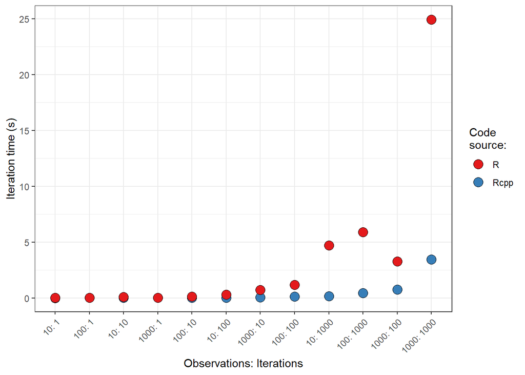

```r
bp_time_df <- bench_press %>%
  mutate(rows = 1:n(),
    expression = as.character(expression)) %>%
  select(-result, -memory, -gc) %>%
  split(.$rows) %>%
  map_dfr(~ unnest_legacy(.x, time))

bp_time_df %>%
  group_by(obs, iters, expression) %>%
  summarise(median = first(median)) %>%
  ungroup() %>%
  mutate(combo = paste0(obs, ": ", iters)) %>%
  arrange(median, combo) %>%
  mutate(combo = fct_inorder(combo)) %>%
  ggplot(aes(combo, median, fill = expression)) +
  geom_point(shape = 21, size = 4) +
  labs(x = "Observations: Iterations",
    y = "Iteration time (s)",
    fill = "Code\nsource:") +
  theme_bw() +
  theme(axis.text.x = element_text(angle = 45, hjust = 1)) +
  scale_fill_brewer(palette = "Set1")
```

## Visualization of results from functions

Essentially this was a bootstrapping problem. Below, we take the largest set of results (i.e, most iterations and observations) from `bench` and plot them. Shaded area represents the 88th percentile of all runs. The “traces” are a sample of individual runs (n = 250). As the number of “observations”, associated with the `micro` object, and “iterations” gets larger, the two sets of code should converge on a similar set of uncertainties, though individual runs will still be variable. I could ensure similarity between runs by setting a “seed”, but I’ve chosen not to do that.

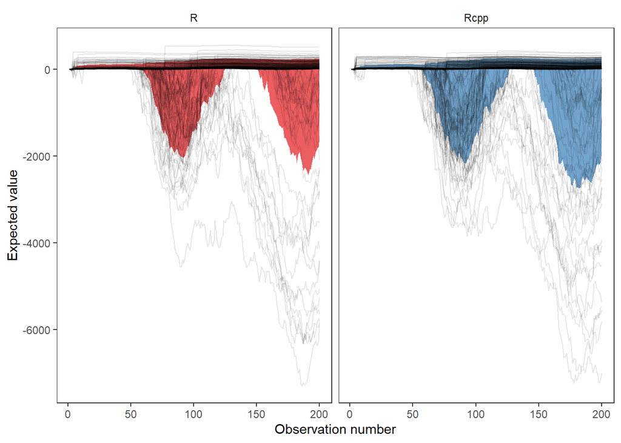

```r
R <- bench_press %>%
  mutate(expression = as.character(expression)) %>%
  filter(obs == max(obs), iters == max(iters), expression == "R") %>%
  select(result) %>%
  unnest_legacy()

Rcpp <- bench_press %>%
  mutate(expression = as.character(expression)) %>%
  filter(obs == max(obs), iters == max(iters), expression == "Rcpp") %>%
  select(result) %>%
  unnest_legacy()

code_summary <- lst(R, Rcpp) %>%
  map_dfr( ~ .x %>%
  as_tibble() %>%
  mutate(obs_num = 1:n()) %>%
  pivot_longer(cols = -obs_num, names_to = "iteration", values_to = "value") %>%
  mutate(iteration = parse_number(iteration)) %>%
  group_by(obs_num) %>%
  summarise(median = quantile(value, probs = 0.5, na.rm = TRUE),
    high = quantile(value, probs = 0.94, na.rm = TRUE),
    low = quantile(value, probs = 0.06, na.rm = TRUE)),
    .id = "source")

code_sample <- lst(R, Rcpp) %>%
  map_dfr(~ .x %>%
      as_tibble() %>%
  mutate(obs_num = 1:n()) %>%
  pivot_longer(cols = -obs_num, names_to = "iteration", values_to = "value") %>%
  mutate(iteration = parse_number(iteration)) %>%
  group_by(iteration) %>%
  nest() %>%
  ungroup() %>%
  sample_n(250) %>%
  unnest(cols = c(data)),
    .id = "source")

ggplot() +
  geom_ribbon(data = code_summary,
    aes(x = obs_num, ymin = low, ymax = high, fill = source),
    alpha = 0.7, show.legend = FALSE) +
  geom_line(data = code_sample,
    aes(x = obs_num, y = value, group = iteration),
    alpha = 0.1) +
  labs(x = "Observation number",
    y = "Expected value") +
  facet_wrap(~ source) +
  theme_bw() +
  theme(panel.grid = element_blank(),
    strip.background = element_blank()) +
  scale_fill_brewer(palette = "Set1")
```